# Gestión

En las empresas, la actividad de la **gestión** se lleva a cabo diariamente para mejorar los resultados del trabajo. Conocer y poner en práctica los conceptos básicos de la gestión permite mejora la calidad del trabajo y ofrecer productos de forma estable y continua.

- Comprensión de las actividades de gestión.
- Comprensión de cómo proceder con el trabajo.
- Comprensión del ciclo PDCA.
- Comprensión del ciclo SDCA.
- Comprensión de los puntos de control.

[Audio_1](https://drive.google.com/file/d/1bjWZ-SwmE_Ii3JefG-Rb5eiNkcPnh2yB/view?usp=drive_link)

```python
import os

try:
  os.chdir('../Python/QCKentei4')
except:
  pass

path = os.getcwd()
path
```

```
'/Users/takanohiroshi/Library/CloudStorage/OneDrive-個人用/Documenten/Python/QCKentei4'
```

```python
from PIL import Image
```

## 02-01 Actividades de gestión

### (1) Actividades de mantenimiento

**Actividades de mantenimiento**: La ejecución de las tareas diarias. Son las actividades destinadas a llevar a cabo la provisión de productos y servicios de manera uniforme, estable y continua.

- Establecer estándares apropiados / adecuados
- Educación y capacitación / Formación
- **SDCA**

### (2) Actividades de mejora

**Actividades de mejora**: iniciativas para lograr mejores formas de trabajar y ofrecer mejores productos o servicios.

- Mejora de calidad
- Reducción de costos / Disminución de costos
- **PDCA**

### (3) Actividades de gestión

**Actividades de gestión**: la combinación de actividades de mantenimiento y actividades de mejora.

- Colaboración de toda la organización / Cooperación de toda la organización
- Mejora del nivel de toda la organización

[Audio_2](https://drive.google.com/file/d/1P5CeeJr7_g1h9Z0XhaUKnmBzDovrwVlj/view?usp=drive_link)

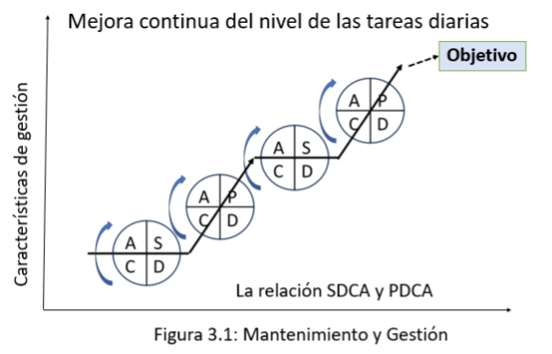

```python
img = Image.open('../QCKentei3/Graph3/PDCA.png')
display(img)
```

## 02-02 Metodología de trabajo / Manera de trabajar / Cómo llevar a cabo el trabajo

### (1) Organización y trabajo

- Medios para alcanzar los objetivos / Instrumentos para lograr los objetivos.
- **PDCA**

### (2) PDCA

El PDCA es un concepto que busca mejorar el nivel de los procesos mediante la aplicación constante y continua de sus cuatro etapas:

- Planificar (Plan),
- Hacer (Do),
- Verificar (Check)
- Actuar (Act).

Para mejorar la calidad del trabajo, los productos o la calidad de los servicios, es necesario implementar el ciclo PDCA de manera efectiva.

[Audio_3](https://drive.google.com/file/d/1Ty3OpDZoSl1dKL98CZxZ8hxf4eHqtCez/view?usp=drive_link)

```
Problema y Desafio
```

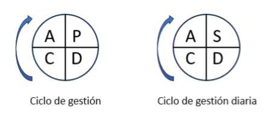

```python
print("Problema y Desafio")
img = Image.open('./Data4/PDCA-SDCA.png')
display(img)
```

## 02-03 PDCA, SDCA

### 1. PDCA

- Implementar el ciclo de gaestión / Llevar a cabo el ciclo PDCA / Ejecutar el ciclo PDCA / Poner en marcha el cilco PDCA

#### (1) Plan (P)

Planificar es elaborar un plan de trabajo

- 5W1H

#### (2) Do (D)

Hacer es llevar a cabo el trabajo de acuerdo con el plan elaborado en la etapa de Planificación.

- Preparación (aseguramiento de recursos, educación y capacitación, etc.)
- Observación del estado de implementación / Observación del progreso de la implementación

#### (3) Check (C)

Verificar consiste en comparar el trabajo realizado en la etapa de Hacer con el plan de la etapa de Planificación, para confirmar, inspeccionar y evaluar el estado de las actividades y los resultados obtenidos.

- Determinar la causa raís / Investigar la causa raíz
- Escala numérica / Métrica numérica

#### (4) Act (A)

Actuar consiste en tomar medidas, basándose en los resultados de la etapa de Verificar y, si es necesario, abordando las causas y los efectos de las diferencias entre el plan y los resultados obtenidos.

- Causa
- Efecto / Impacto
- Para que no vuelva a ocurrir / Para evitar que ocurra de nuevo / Para prevenir su recurrencia / Para que no se repita

### 2. SDCA

El SDCA es un concepto que enfatiza la importancia de aplicar de manera constante y continua sus cuatro etapas - Estandarizar (Standardize), Hacer (Do), Verificar (Check) y Actuar (Act) - para repetir el trabajo de forma estable y continya. Cabe mencionar que las etaps de Hacer, Verificar y Actuar son las mismos que en el ciclo PDCA.

- Establecer un estándar / Fijar un estándar
- Trabajar compliendo el estándar / Trabajar siguiendo el estándar

[Audio_4](https://drive.google.com/file/d/1XdTf7T1c13NV0sbELV5DujuC1lKC1kwb/view?usp=drive_link)

## 02-04 Ítem de gestión

Media utiizada para verificar, inspeccionar y evaluar si los objetivos se lograron mediante las actividades, siendo deseable qaue pueda ser cuantificable.

- Logro de objetivos / Consecución de objetivos
- Ítem de gestión de resultados / Elemento de gestión de resultados *Ïtem de gestión de factores (Ítem de verificación) / Elemento de gestión de factores (Elemento de verifcicación)

[Audio_5](https://drive.google.com/file/d/1pCeX-nk5HTRHbvvrJRhXVEu_Lyuch5gI/view?usp=drive_link)

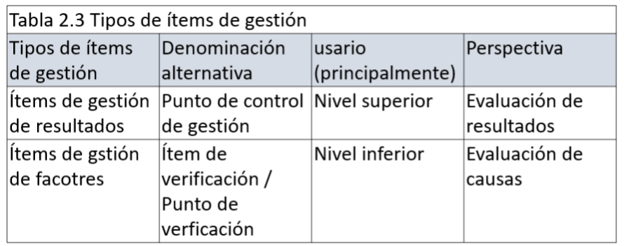

```python
img = Image.open('./Data4/Tabla2-3.png')
display(img)
```

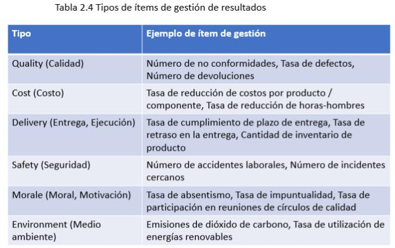

```python
img = Image.open('./Data4/Tabla2-4.jpg')
display(img)
```

```python
from IPython.display import display
from PIL import Image
import gdown
import re

def get_file_id(url,out):
    # 正規表現でファイルIDを抽出
    match = re.search(r'/d/([a-zA-Z0-9_-]+)', url)

    if match:
        file_id = match.group(1)
        print("ファイルID:", file_id)
    else:
        print("ファイルIDが見つかりませんでした。")

    url = f"https://drive.google.com/uc?id={file_id}"

    output = out

    gdown.download(url, output, quiet=False)

    img = Image.open(out)
    display(img)
```

```
ファイルID: 1x4qN4_cMd3FVFUXfcDVjBRCsK-pBPMeE
```

```
Downloading...
From: https://drive.google.com/uc?id=1x4qN4_cMd3FVFUXfcDVjBRCsK-pBPMeE
To: /Users/takanohiroshi/Library/CloudStorage/OneDrive-個人用/Documenten/Python/QCKentei4/Data4/PDCA-SDCA.png
```

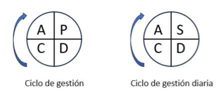

```python
url= 'https://drive.google.com/file/d/1x4qN4_cMd3FVFUXfcDVjBRCsK-pBPMeE/view?usp=drive_link'
out = './Data4/PDCA-SDCA.png'
get_file_id(url,out)
```

```
ファイルID: 1x5p7MU3Opt8qSpJxHgCiMsChNIGCz_O1
```

```
Downloading...
From: https://drive.google.com/uc?id=1x5p7MU3Opt8qSpJxHgCiMsChNIGCz_O1
To: /Users/takanohiroshi/Library/CloudStorage/OneDrive-個人用/Documenten/Python/QCKentei4/Data4/Tabla2-3.png
```

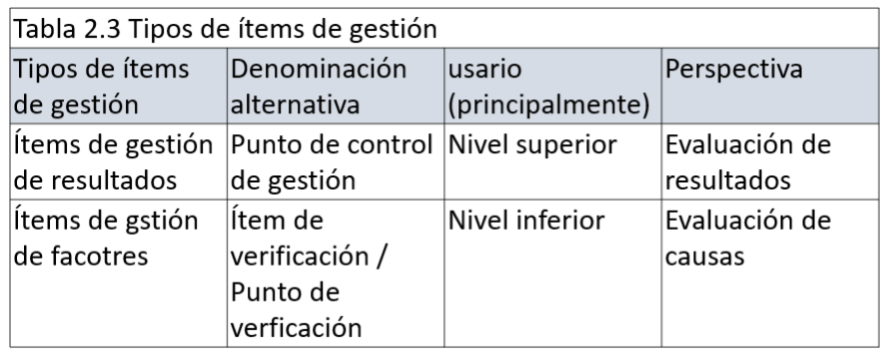

```python
url= 'https://drive.google.com/file/d/1x5p7MU3Opt8qSpJxHgCiMsChNIGCz_O1/view?usp=drive_link'
out = './Data4/Tabla2-3.png'
get_file_id(url,out)
```

```
ファイルID: 1__PlJ1sVG-dRd2QXua5tlcBCUQfiZm19
```

```
Downloading...
From: https://drive.google.com/uc?id=1__PlJ1sVG-dRd2QXua5tlcBCUQfiZm19
To: /Users/takanohiroshi/Library/CloudStorage/OneDrive-個人用/Documenten/Python/QCKentei4/Data4/Tabla2-4.jpg
```

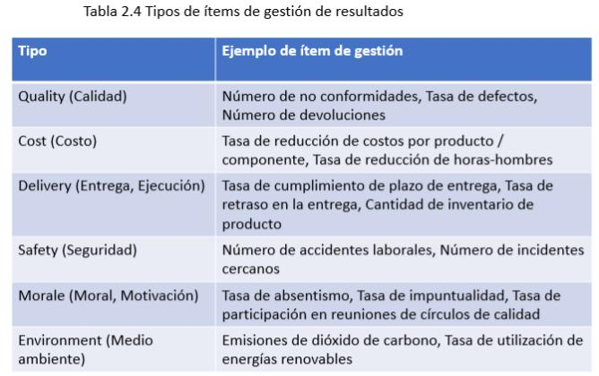

```python
url= 'https://drive.google.com/file/d/1__PlJ1sVG-dRd2QXua5tlcBCUQfiZm19/view?usp=drive_link'
out = './Data4/Tabla2-4.jpg'
get_file_id(url,out)
```

```python
notebook_name = 'QCKentei4-2.ipynb'
notebook_name_html = notebook_name.replace(".ipynb",".html")

!jupyter nbconvert --to html {notebook_name}
```

```
[NbConvertApp] Converting notebook QCKentei4-2.ipynb to html
[NbConvertApp] Writing 1928538 bytes to QCKentei4-2.html
```